# Лабораторная работа №11

Операционные системы - Бекауов А.Т

Российский университет дружбы народов, Москва, Россия

# Введение

## Цель работы

Цель данной лабораторной работы - получить практические навыки работы с редактором Emacs.

# Выполнение лабораторной работы

## Запуск Emacs

Введя в терминале команду emacs, открываю текстовый редактор Emacs.

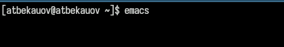

## Создание и открытие файла

Далее нажав комбинации клавиши Ctrl-x и Ctrl-f, создаю и открываю файл lab07.sh.

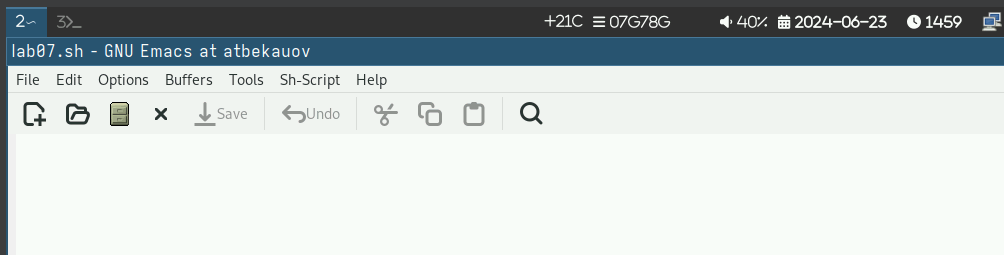

## Ввод текста

Затем ввожу в файл текст, приложенный в методичке к лабораторной работе.

[figure not shown]

## Сохранение файла

После этого прожимаю комбинации клавиш Ctrl-x и Ctrl-s и сохраняю изменения в файле.

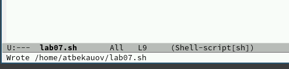

## Вырезание и вставка строки

С помощью комбинации Ctrl-k вырезаю (коопирую и удаляю) 5-ую строку и ,переведя курсор в конец файла, прожимаю комбинацию Ctrl-y, которая вставляет скопированную строку.

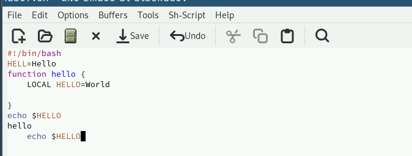

## Выделение и копирование текста

Далее устанавливаю курсор в начале второй строки и прожимаю комбинацю Ctrl-space, которая позволяет мне выделять текст перемещая курсор. Выделяю строки со 2-ой по 4-ую и копирую их, нажав Alt-w

[figure not shown]

## Вставка текста

Далее с помощью комбинации Ctrl-y, вставляю скопированный текст в конец.

[figure not shown]

## Вырезание текста

Вновь выделяю (Ctrl-space) ,только что вставленный, текст и нажав комбинацию Ctrl-w, вырезаю выделенный текст.

[figure not shown]

## Отмена последнего действия

Затем с помощью комбинации Ctrl-/ отменяю последнее действие, возвращая обратно выделенный текст.

[figure not shown]

## Перемещение по файлу

Перемещение по файлу происходит с помощью стрелок, которые перемещаю курсор по символом. Также с помощью комбинаций Ctrl-a (курсор в начало строки), Ctrl-e (курсор в конец строки), Alt-< (курсор в начало буфера), Alt-> (курсор в конец буфера).

## Список активных буферов

Нажав комбинации клавиш Ctrl-x и Ctrl-b, вывожу список активных буферов на экран

[figure not shown]

## Перемещение в активный буфер

Затем перехожу к списку, нажав Ctrl-x и o, перехожу к списку и нажав enter напротив scratch перехожу в этот буфер.

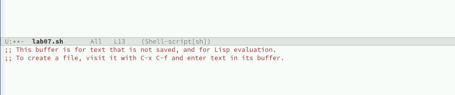

## Закрытие окна

После комбинацией Ctrl-x и 0, закрываю окно.

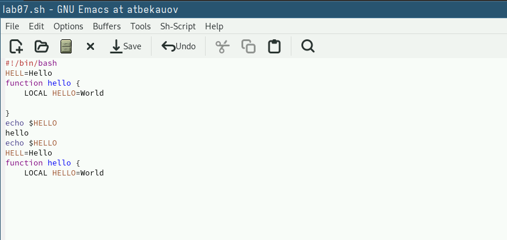

## Перемещение в буфер без списка

Далее с помощью комбинации Ctrl-o и b, переключаюсь в другой буфер без вывода списка

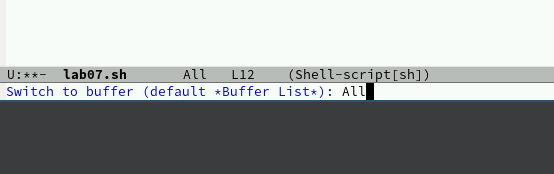

## Деление фрейма на 4 окна

Затем разделяю фрейм на 4 части, комбинациями Ctrl-x и 3 (делит фрем на два окна по вертикали), Ctrl-x и 2(делит каждое из этих окон на две части по горизонтали)

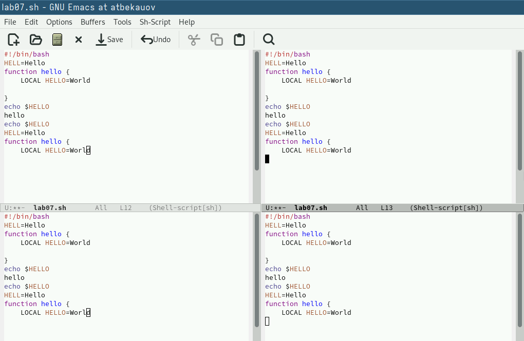

## Открытие 4 файлов в 4 окнах

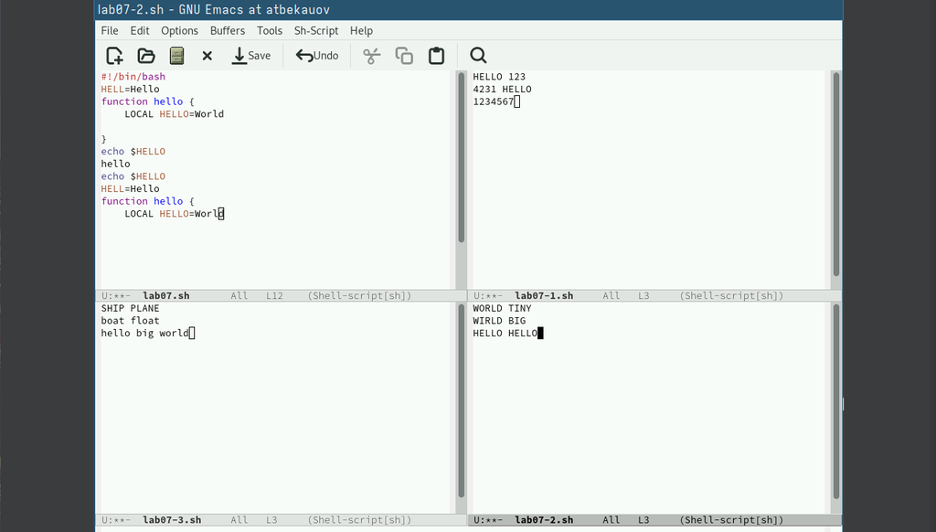

## Режим поиска Ctrl-s

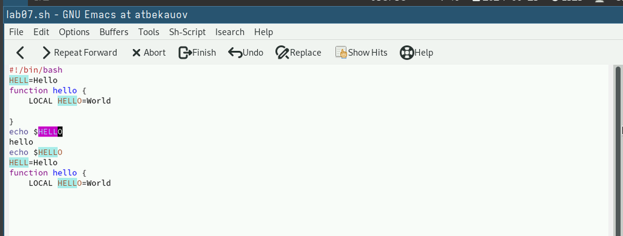

## Режим поиска и замены

Выхожу из режима поиска с помощью комбинации Ctrl-g (Отмена текущего действия). Перехожу в режим поиска и замены, нажав Alt-%. Ввожу слово HELLO, и нажимаю ENTER, в тексте стали подсвечены все варианты этого слова и мне предлагается ввести слово на замену.

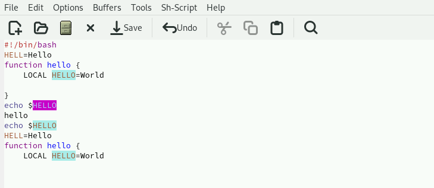

## Замена

Ввожу слово BIG и нажимаю !, чтобы начать замену.

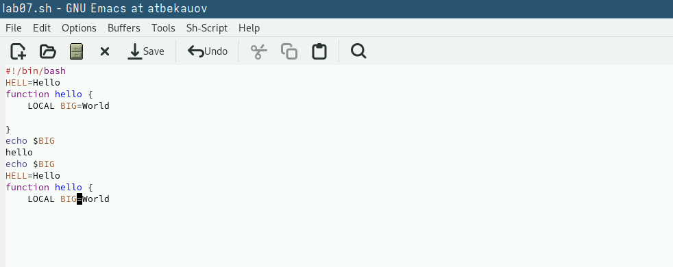

## Второй режим поиска

Рассмотрим режим поиска, вызываемый комбинацией Alt+s и o. Он отличается от обычного тем, что совпадения выводятся в отдельном окне в виде списка нумерованных строк из текста, в котором они появляются.

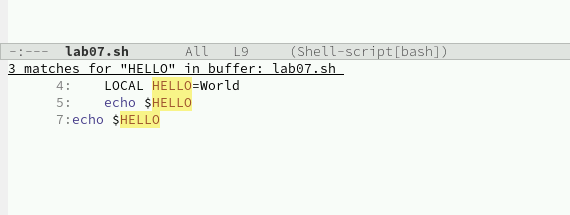

# Заключение

## Выводы

В ходе данной лаботраторной работы я получил практические навыки работы с редактором Emacs.